# Detección y tratamiento de datos faltantes: **missing data**

J. David Ramos

2020-06-11

# **Valores faltantes: introducción**

### **Los valores faltantes (Missing values ó missing data)**

Son valores $x_{ij}$ de la observación $x_i$ que no constan en el conjunto de datos debido a cualquier acontecimiento, como por ejemplo:

- Errores en la transcripción de los datos,
- Ausencia de disposición para la respuesta en un individuo observado o,
- La imposibilidad de realizar la medición u observación misma.

### **Consecuencias de los valores faltantes:**

1. **Sesgo**: diferencia notable entre valores observados y valores no observados.
2. **Laboriosidad**: hacen el entrenamiento y el manejo de datos más complicado.
3. **Pérdida de información**: se reduce la potencia de predicción o descripción, por ejemplo.

### **Tipos de valores faltantes**

Los valores perdidos son un subconjunto del conjunto de datos y el observarlos puede obedecer a un proceso aleatorio o no aleatorio:

**$1.$ Valores faltantes completamente aleatorios** (*Missing Completely at Random*, **MCAR**)

- El proceso de la pérdida no depende de las otras variables observadas (pej. *equipo no funcionaba correctamente, el clima era terrible, la gente se enfermó, o los datos no se capturaron correctamente.*).
- Los valores “reales” (no observados) son aleatorios.
- Los *MCAR* no siguen ningún patrón en su “observación” dentro de los datos.
- Son los más sencillos de manipular. Sin embargo, casi nada es *MCAR*
- Con los datos *MCAR* se pierde potencia de predicción pero no bondad de ajuste.

**$2.$ Valores faltantes aleatorios** (*Missing at Random*, **MAR**)

- Las observaciones faltantes están condicionadas por otras variables observadas en el conjunto de datos (pej. *ingresos vs. baja autoestima*, *abuso sexual vs. situación social*).
- Los valores “reales” (no observados) son aleatorios.
- Los *MAR* con frecuencias siguen algunos patrones.
- Su tratamiento depende de otras variables observadas. Más complicado
- Con los datos *MAR* se pierde potencia de predicción pero no bondad de ajuste.

**$3.$ Valores faltantes no aleatorios** (*Missing Not At Random* **MNAR**)

- Un valor es *MNAR* cuando su ausencia depende de valores de variables no observadas en el conjunto de datos.
- Su tratamiento depende de otras variables y valores no observados (casi imposible).
- Su distribución presenta patrones, pues su pérdida es no aleatoria.
- Con los datos *MNAR* se pierde potencia de predicción y bondad de ajuste.

# **Tratamiento de valores faltantes**

Hay una serie de formas alternas de tratar con valores perdidos:

### **1. Supresión de observaciones incompletas**

- Cuando el número de observaciones con al menos un valor perdido es pequeño (menos de $5\%$ con relación conjunto), se eliminan del conjunto dichas observaciones (**casos incompletos**) y se procede al entrenamiento.
- El análisis sólo con casos completos recibe el nombre de **listwise**

### **2. Supresión de variables**

Se suprime la(s) variable(s) que contiene(n) valores faltantes (más de $50\%$). **Poco recomendable**.

### **Imputación:** proceso por el cual se sustituye un valor faltante $x_{ij}$ por una estimación $x_{ij}^*$ de dicho valor. $x_{ij}^*$ recibe el nombre de **valor imputado** y corresponde al valor más plausible de $x_{ij}$.

### **3. Imputación simple**

Se sustituyen los valores faltantes por estimaciones de dichos valores:

$a.$ Por un valor de tendencia central no condicionado de la variable correspondiente (**Imputación por media, mediana, moda, etc. no condicionada**).

$b.$ formar categorías a partir de covariables correlacionadas con la variable de interés, e imputar los datos faltantes con un valor de tendencia central de la submuestra que comparte características comunes (**Imputación por medias, mediana,moda, etc. condicionadas para datos agrupados**).

### **4. Imputación mediante distribuciones no condicionadas**

- Se reemplaza cada valor perdido $x_{ij}$ de un caso incompleto $x_{i}$ con un valor plausible $x_{ij}^*$ obtenido a partir de casos completos $x_{k}$ (con $i\neq k$) semejantes a la observación incompleta.
- Este método recibe también el nombre de **imputación hot-deck** y es un método no paramétrico

### **5. Imputación por regresión:**

- Ante la presencia de un patrón de valores faltantes es posible utilizar modelos de regresión para imputar información en la variable $Y$, a partir de un grupo de variables predictoras $X$ correlacionadas.
- Consiste en ajustar un modelo $Y=f(X)+\epsilon$ con los casos completos e imputar el valor $y_{i}$ faltante por el correspondiente valor predicho $\widehat{y}=\widehat{f}(x)$.

### **Imputación múltiple:**

- Consiste en realizar $m$ imputaciones simples por regresión para cada valor perdido $x_{ij}$ en la variable $X_j$ con base en todas las covariables relacionadas.
- Con base en las $m$ iteracciones se generan $m$ conjuntos de datos **completos**.
- Sobre los $m$ conjuntos de datos se ajustan $m$ modelos de regresión
- Finalmente, con base en los $m$ modelos se construye un **modelo de regresión ponderado**, cuyos valores predichos serán las imputaciones de los $x_{ij}$:

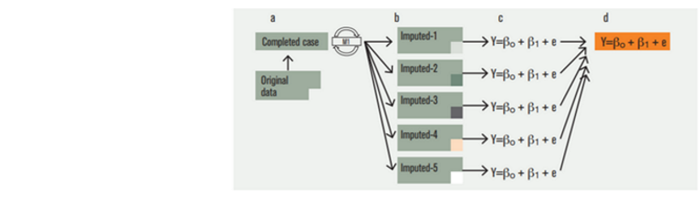

Existen muchos otros métodos de imputación, algunos de ellos muy sofisticados, basados en métodos de estimación y modelado. Se destacan: **Estimación por máxima verosimilitud**, **imputación por variables ficticias** , etc.

# **Datos simulados con NA’s y <NA’s>**

1. Paquetes necesarios para trabajo con NA’s

```r
library(tidyverse)
library(finalfit) # Ajuste y visualización de modelos
library(Amelia) # Métodos de imputación de NA's
library(DataExplorer) # Visualización de datos
library(mice) # Imputación múltiple de NA's
library(VIM) # Incluye función para imputación por kNN
```

2. Importando conjunto de datos `diamonds` sin NA’s del paquete `ggplot2`

```r
# Selección de datos de trabajo
datos<-ggplot2::diamonds%>%select(cut,carat,price)

# Estructura de datos
dplyr::glimpse(datos)
```

```
## Rows: 53,940
## Columns: 3
## $ cut   <ord> Ideal, Premium, Good, Premium, Good, Very Good, Very Good, Ve...
## $ carat <dbl> 0.23, 0.21, 0.23, 0.29, 0.31, 0.24, 0.24, 0.26, 0.22, 0.23, 0...
## $ price <int> 326, 326, 327, 334, 335, 336, 336, 337, 337, 338, 339, 340, 3...
```

```r
# ¿Hay valores faltantes en "datos"?
any(is.na(datos))
```

```
## [1] FALSE
```

```r
# Aleatoriamente se crea un conjunto de valores fila/columna para borrar
set.seed(979)
col<-sample(2:3,15000,replace=T)
row<-sample(nrow(datos),15000,replace=T)
missing<-data.frame(row,col)

#################################################################################

# Asignar NA's a la celdas seleccionadas. El conjunto de datos con valores perdidos es dat1
dat1<-datos
for(i in 1:nrow(missing))
  dat1[missing[i,1],missing[i,2]]<-NA
```

4. Se construye una nueva variable ficticia con valores *MAR* condicionadas a `cut` (calidad de corte del diamante)

```r
# Se agrega la variable color a dat1
dat1$colorMAR<-diamonds$color

# NA´s en colorMAR condicionada a "Very Good" en cut
set.seed(1234)
dat1$colorMAR[dat1$cut=="Very Good"]<-
  sample(c("D", "E", "F", "G", "H", "I", "J", NA),
    sum(dat1$cut=="Very Good"),
    replace = TRUE,
    prob = c(rep(0.1,7),0.3))

# NA´s en colorMAR condicionada a "Premium" en cut
set.seed(1234)
dat1$colorMAR[dat1$cut=="Premium"]<-
  sample(c("D", "E", "F", "G", "H", "I", "J", NA),
    sum(dat1$cut=="Premium"),
    replace = TRUE,
    prob = c(rep(0.1,7),0.3))
```

# **Detección y conteo global de NA’s**

1. El conjunto de datos `dat1` tiene valores faltantes, entonces la primera tarea consiste detectarlos y determinar su número (filas/columnas) de manera global

```r
# '¿Hay NA's dentro del conjunto de datos?
any(is.na(dat1))
```

```
## [1] TRUE
```

```r
# Resumen de datos para detectar NA´s
summary(dat1)
```

```
##         cut            carat           price          colorMAR
##  Fair     : 1610   Min.   :0.200   Min.   :  326   G      :8758
##  Good     : 4906   1st Qu.:0.400   1st Qu.:  950   E      :7670
##  Very Good:12082   Median :0.700   Median : 2406   F      :7555
##  Premium  :13791   Mean   :0.797   Mean   : 3935   H      :6763
##  Ideal    :21551   3rd Qu.:1.040   3rd Qu.: 5330   D      :6228
##                    Max.   :5.010   Max.   :18823   (Other):9292
##                    NA's   :6976    NA's   :7071    NA's   :7674
```

```r
# Función para calcular número de celdas con NA's
na.number<- function(x){sum(is.na(x))}
na.number(dat1)
```

```
## [1] 21721
```

```r
# Porcentaje de NA's con respecto al total de valores
na.number(dat1)/(nrow(dat1)*ncol(dat1))*100
```

```
## [1] 10.0672
```

### **Ejercicios**

A. Verifique qué tareas realizan las funciones `is.na()` y `complete.cases()` del paquete `stats` de `R`

B. Construya un gráfico que le permita identificar visualmente la distribución de los valores faltantes dentro del conjunto de datos.

### **$2.$ Detección y conteo de `NA's` por filas o columnas**

La siguiente etapa es ubicar la posición del `NA` dentro del conjunto de datos (fila/columna). Para esta etapa son útiles las funciones `is.na()` y `complete.cases()`.

```r
# Identificar fila/columna donde está el valor pérdido
ubic.NA<-which(is.na(dat1)==TRUE,arr.ind = TRUE)

# Retorna las filas con al menos, un valor perdido
ubic.NA2<-dat1[!complete.cases(dat1),]

# Porcentaje de observaciones (filas) con al menos un valor faltante dentro de los datos
incompletos<-nrow(dat1[!complete.cases(dat1),])
porcentaje<-incompletos/nrow(dat1)*100
```

### **Ejercicio**

A. Cree una función que cuente el número de valores faltantes por variable. Denomine a esta función `totalcol.NA`. **Pista:** puede utilizar la función `apply()` y la función `is.na()`.

B. Construya un gráfico adecuado que represente la proporción de valores consistentes versus la proporción de valores faltantes para cada variable del conjunto de datos.

### **Visualización de valores faltantes en `R`**

La visualización de los `NA's` dentro del conjunto de datos puede ser muy útil. Algunas librerías apropiadas para este trabajo son `Amelia`, `DataExplorer` y `finalfit`:

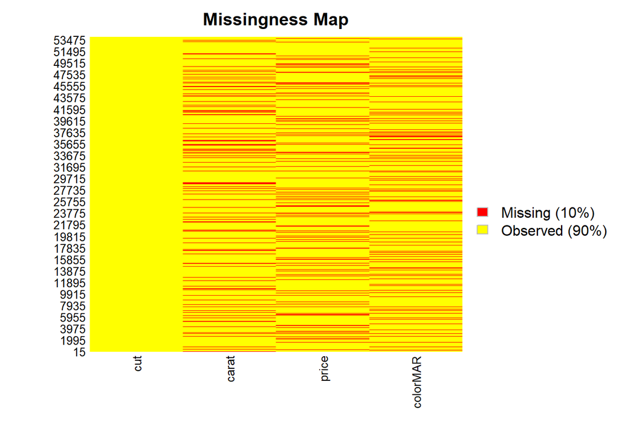

```r
# Distribución de los NA's en el conjunto de datos (Missing plot)
Amelia::missmap(obj=dat1,col=c("red","yellow"),rank.order = F,legend = T)
```

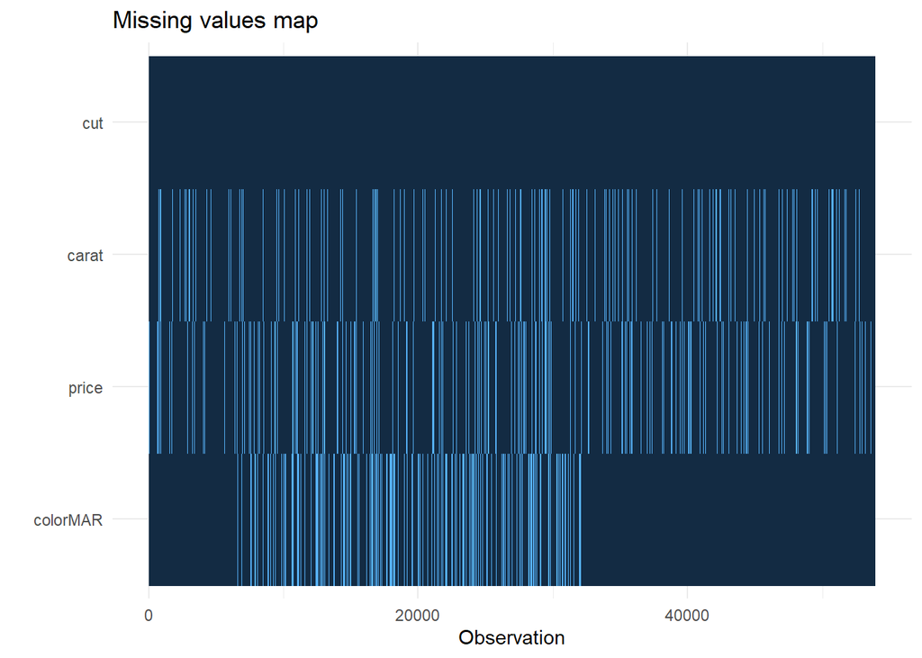

```r
#Lo mismo, pero con finalfit (ordenando cut)
dat1%>%arrange(cut)%>%missing_plot()
```

```r
# Tabla con proporción de valores faltantes por variable
dat1%>%DataExplorer::profile_missing()
```

```
## # A tibble: 4 x 3
##   feature  num_missing pct_missing
##   <fct>          <int>       <dbl>
## 1 cut                0       0
## 2 carat           6976       0.129
## 3 price           7071       0.131
## 4 colorMAR        7674       0.142
```

```r
# Tabla con proporción de valores faltantes por variable con finalfit
dat1%>%finalfit::missing_glimpse()
```

```
##             label var_type     n missing_n missing_percent
## cut           cut    <ord> 53940         0             0.0
## carat       carat    <dbl> 46964      6976            12.9
## price       price    <int> 46869      7071            13.1
## colorMAR colorMAR    <ord> 46266      7674            14.2
```

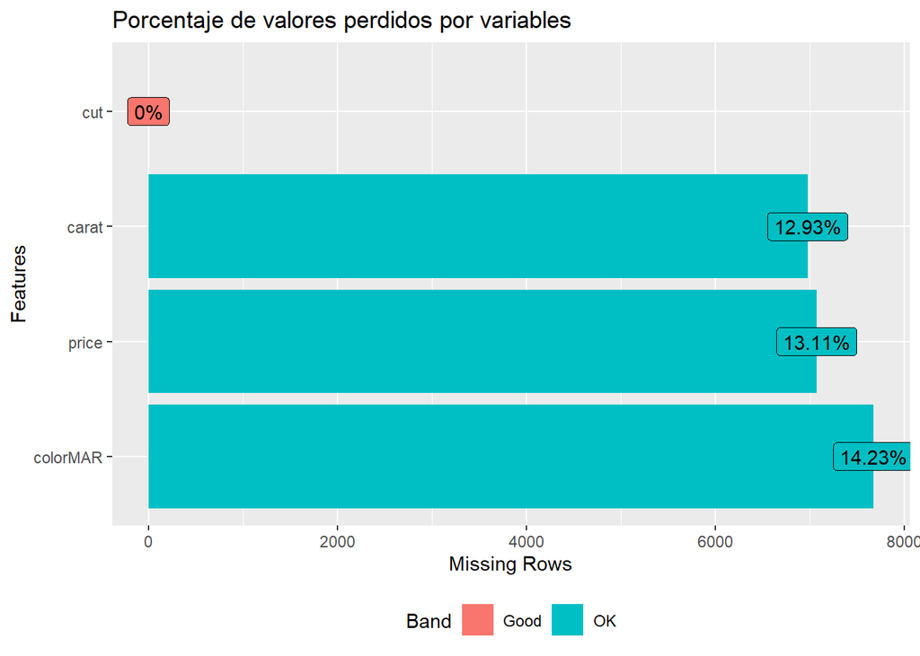

```r
# Gráfica con proporción de valores faltantes por variable
DataExplorer::plot_missing(data=dat1,title = "Porcentaje de valores perdidos por variables")
```

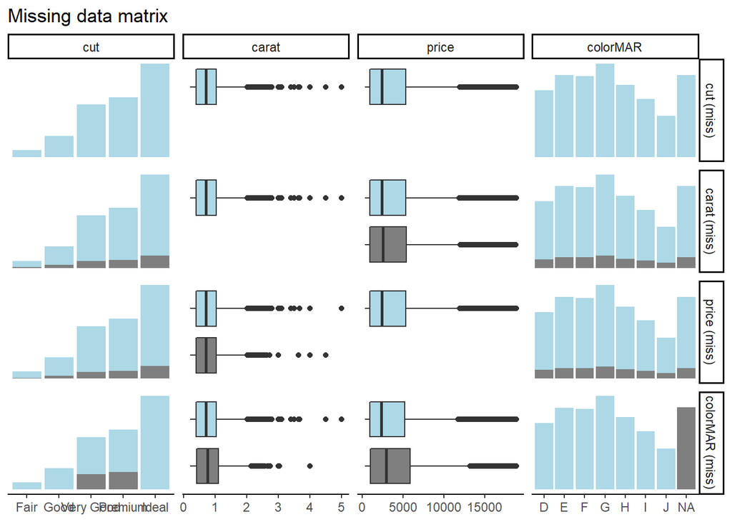

```r
# Distribución de NA's por categorias de la variable "cut"
explicativas<-names(dat1)[2:4]

dat1%>%
finalfit::missing_pairs(dependent = "cut",explanatory =explicativas)
```

# **Suprimiendo missing: Listwise**

### **La regla de remoción del $5\%$**

Suponiendo que la proporción de observaciones (filas) con valores perdidos dentro del conjunto de datos no es muy grande (menor al $5\%$ del total de filas), se pueden extraer dichas observaciones. Esto se logra con la función `na.omit()`

```r
#Se extraen las observaciones incompletas generando un conjunto con
# sólo observaciones completas
newdata1<-na.omit(dat1)

# verificación
any(is.na(newdata1))
```

```
## [1] FALSE
```

```r
# Dimensión data frame sin NA's
dim(newdata1)
```

```
## [1] 35024     4
```

```r
# Dimensión data frame original
dim(dat1)
```

```
## [1] 53940     4
```

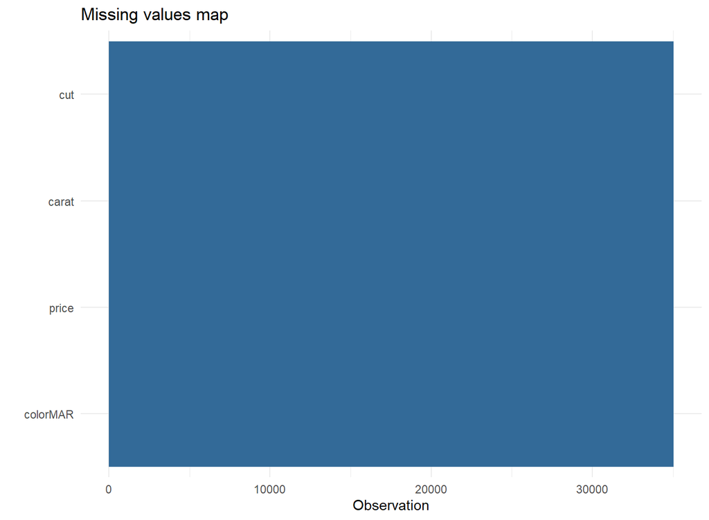

```r
# Mapa con posibles NA's
newdata1%>%finalfit::missing_plot()
```

### **Otras reglas de remoción**

- **variable:** con $\%$ límite de NA´s, elimine dicha variable
- **fila:** con $\%$ límite de NA´s, elimine dicha fila

### **Ejercicio**

A. Utilice las funciones `complete.cases()` y `filter()` para seleccionar y almacenar en un nuevo data frame `newdata2` sólo las observaciones completas de `dat1`, y en un data frame `newdata2` las observaciones incompletas

B. Realice la misma tarea del literal anterior, pero esta vez utilice la función `na.omit()` de `stats`.

C. Cree una función que remueva primero del conjunto de datos `dat1` la(s) variable(s) que tenga(n) más del $14\%$ de valores faltantes, y luego remueva las observaciones con más de un $70\%$ de NA’s. Verifique el tamaño del conjunto de datos resultante después de la remoción.

D. Cree una función que remueva primero del conjunto de datos `dat1` las observaciones con más de un $50\%$ de NA’, y luego la(s) variable(s) que tenga(n) más del $14\%$ de valores faltantes. Verifique el tamaño del conjunto de datos resultante después de la remoción.

# **Imputación simple de NA’s**

- La **imputación simple** se recomienda cuando la proporción de observaciones incompletas es grande en relación a las observaciones completas.
- Si toman en cuenta sólo las **variables cuantitativas** las imputaciones para los `NA's` puede ser la media, la mediana, la trimedia o cualquier otro estadístico de centralidad de las variables en cuestión.

Se recomienda la mediana, por ejemplo, cuando la distribución de la variable a imputar es muy asimétrica. En caso contrario, es adecuada la media.

- Si toman en cuenta sólo las **variables cualitativas** las imputaciones para los `NA's` se hacen por la **clase más frecuente**.
- También se puede imputar un `NA` de un variable $X_j$ por un valor $x_{ij}$ seleccionado aleatoriamente de la misma $X_j$. Esto aplica a variables **cuantitativas** o **cualitativas**.
1. Análisis exploratorio de las variables de `dat1`

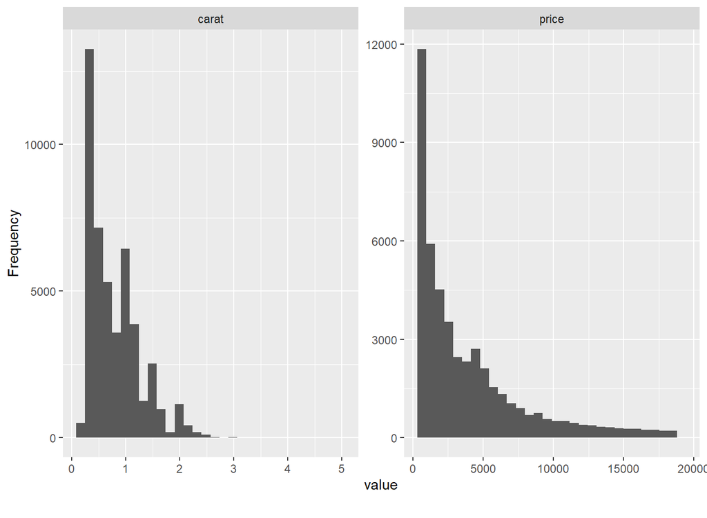

```r
# Histogramas para las variables numéricas de dat1
dat1%>%plot_histogram(ncol = 2)
```

```r
# Selección de variable numéricas a imputar
df.imp<-dat1%>%
  dplyr::select(carat,price)
profile_missing(df.imp)
```

```
## # A tibble: 2 x 3
##   feature num_missing pct_missing
##   <fct>         <int>       <dbl>
## 1 carat          6976       0.129
## 2 price          7071       0.131
```

2. **Imputación simple por la media y/o mediana observada** (no recomendable)

```r
# Imputando por la media para carat
df.imp$carat_imp<-df.imp$carat
df.imp[is.na(df.imp$carat_imp),"carat_imp"] <- mean(dat1$carat, na.rm=T)

# Imputando por la mediana para price
df.imp$price_imp<-df.imp$price
df.imp[is.na(df.imp$price_imp),"price_imp"] <- median(dat1$price, na.rm=T)

# Verificación
df.imp%>%profile_missing()
```

```
## # A tibble: 4 x 3
##   feature   num_missing pct_missing
##   <fct>           <int>       <dbl>
## 1 carat            6976       0.129
## 2 price            7071       0.131
## 3 carat_imp           0       0
## 4 price_imp           0       0
```

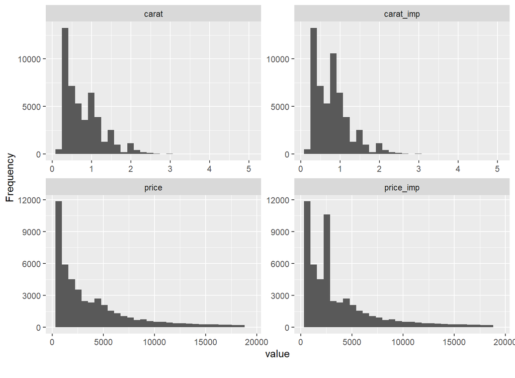

```r
# Comparación de distribuciones
df.imp%>%DataExplorer::plot_histogram(ncol = 2)
```

### **Ejercicio 1**

A. Construya una tabla de resumen con las variables de `df.imp` comparándolas en términos de los estadísticos: media, mediana, varianza y cuartiles

B. ¿Qué criterio tendría presente para asegurar o no que las imputaciones fueron aceptables?

C. Utilice la moda para imputar los valores faltantes en la variable `colorMAR` del conjunto `dat1`. Compare gráficamente las variables con NA’s y las variables imputadas ¿qué puede observar?

### **Imputación simple por muestreo aleatorio de valores observados**

- Otra posibilidad: imputar un valor NA de una variable $X_j$ mediante la selección aleatoria de un valor $x_{ij}$ observado de $X_j$, y luego reemplazándolo en el NA.

### **Ejercicio 2**

Utilice la imputación simple por muestreo aleatorio para imputar la variable `price` del conjunto `dat1`. Compare las distribuciones, gráficamente y a través de medidas descriptivas.

### **Imputación simple vía paquete `mice`**

- El paquete `mice` permite realizar imputación simple (por media y muestreo aleatorio) de manera automática

```r
# Imputación por la media (imputación no condicional por la media) de la variable carat
# Imputación por muestreo simple de la variable price
imputasimple<-mice::mice(data =df.imp[,1:2],method = c("mean","sample"),m = 1,maxit=1)

# Variables imputadas
v.imputadas<-mice::complete(data =imputasimple)

indicadora<-as.data.frame(imputasimple$where)

union0<-dplyr::bind_cols(v.imputadas,indicadora)
names(union0)<-c("carat.mean","price.sample","carat.ind","price.ind")

# Valores imputados de carat por la media
imputados_mean<-union0[union0$carat.ind=="TRUE","carat.mean"]

# Valores imputados de price por muestreo aleatorio
imputados_sample<-union0[union0$price.ind=="TRUE","price.sample"]
```

- Comparación de distribución de valores observados con distribución de valores imputados:

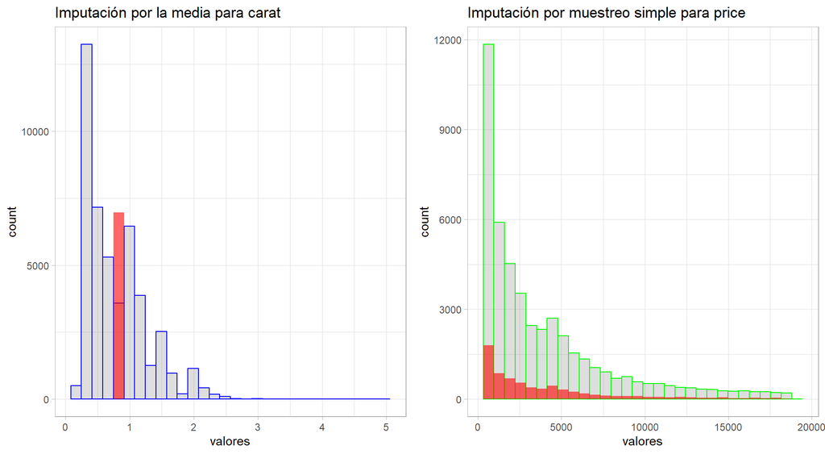

| tipo | min | media | sd | max | Total |
| --- | --- | --- | --- | --- | --- |
| obs.carat | 0.200 | 0.797 | 0.474 | 5.010 | 53940 |
| carat.mean | 0.797 | 0.797 | 0.000 | 0.797 | 6976 |
| obs.price | 326.000 | 3935.172 | 3991.993 | 18823.000 | 53940 |
| price.sample | 352.000 | 3887.840 | 3933.584 | 18787.000 | 7071 |

### Ejercicios

A. Desarrolle un test de bondad de ajuste de *Kolmorogov-Smirnov* entre la variable `carat` y la variable imputada `imputados_mean` ¿Qué significado tiene el resultado de este test?

B. Desarrolle un test de bondad de ajuste de *Kolmorogov-Smirnov* entre la variable `price` y la variable imputada `imputados_sample` ¿Qué significado tiene el resultado de este test?

# **Imputación de NA’s mediante distribuciones no condicionadas**

Es posible utilizar el algoritmo de los **k-vecinos más próximos** (Algoritmo $kNN$ por sus siglas en inglés) para la imputación de valores faltantes mediante distribuciones no condicionadas.

### **Algoritmo**

**Paso 1.** Se establece un valor para el parámetro $k$ (**número de vecinos**).

**Paso 2.** Se buscan las $k$ observaciones completas más próximas (semejantes) a la observación que se desea imputar. La proximidad se establece a partir de una distancia (pej. **euclidianas**).

**Paso 3.** El paso 2 se realiza para todos los casos incompletos, determinando todos los **vecindarios**.

**Paso 4.** Una vez encontrados cada uno de los vecindarios de los casos incompletos, se imputa por la media, la mediana o la moda de los $k$ vecinos más próximos.

**Ventaja:** la distribución de la variable imputada cambia mínimamente

**Desventaja:** computacionalmente es un método muy exhaustivo.

### **Algoritmo kNN para imputación en `R`**

La aplicación en `R` del $kNN$ para imputación se realiza a través de la función `kNN()` del paquete `VIM`. El algoritmo admite todo tipo de variables:

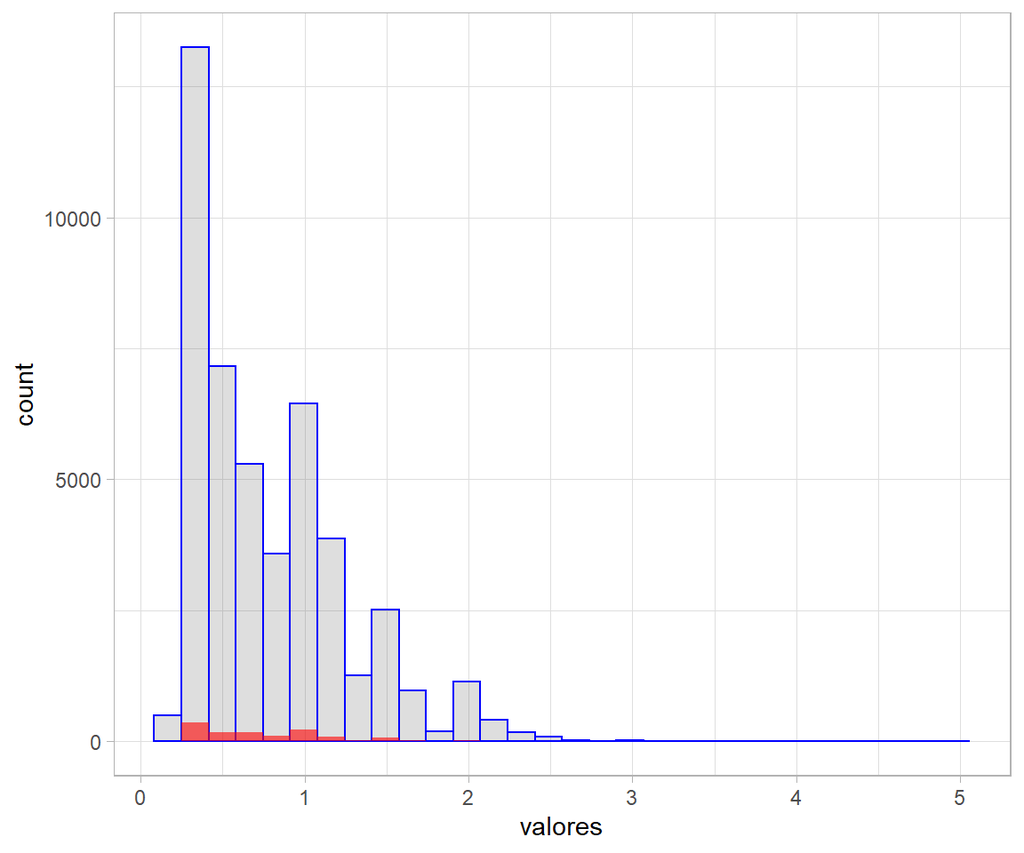

```r
# Aplicación del kNN para imputación con K=5 vecinos utilizando la mediana muestral
# para las variables numéricas y la categoría más frecuentes para las categóricas

# Aplicación de kNN, junto a tiempo de ejecución real
# Se seleccionan aleatoriamente 10000 observaciones de dat1 (por tiempo ejecución)

df.recortado<-dat1%>%sample_n(size = 10000,replace = F)

t <- proc.time() # Inicia el cronómetro
imputacionKnn<-VIM::kNN(data=df.recortado,
                        variable = c("carat","price","colorMAR"),
                        k=5,numFun=median,catFun=maxCat)
ejecucion<-proc.time()-t # tiempo de ejecución

# Valores imputados para la variable carat por kNN
imputados_knn<-imputacionKnn[imputacionKnn$carat_imp=="TRUE","carat"]

# Data frame con variables observadas y variables imputadas por kNN
df.compara<-data.frame(valores=c(imputados_knn,dat1$carat),
                       tipo=c(rep("imputados.Knn",length(imputados_knn)),
                              rep("observados",length(dat1$carat))))

# Histogramas con variables numéricas con NA's e imputadas por kNN
ggplot(data=df.compara,aes(x=valores))+
  geom_histogram(data=subset(df.compara,tipo=="observados"),color = "blue", alpha = 0.2)+
  geom_histogram(data=subset(df.compara,tipo=="imputados.Knn"),fill = "red", alpha = 0.6)+
  theme_light()
```

### **Ejercicio**

A. Realice la imputación con $k=10$ vecinos para todas las variables del data frame `dat1` ¿Cúanto tiempo toma la imputación?

B. Compare gráficamente las distribuciones de las observaciones completas con las imputadas en las variables numéricas y categóricas.

C. Compare, en una tabla de resumen, las medias, medianas y varianzas de las variables observadas versus las variables imputadas por $kNN$.

D. Determine a través de un test KS (para las variables numéricas) cuales imputaciones parecen ser adecuadas.

# **Imputación de NA’s por regresión**

### **Algoritmo**

Suponga un conjunto de $X_p$ variables ($1<j<p$), donde $X_j$ tiene NA’s. La imputación por regresión comprende las siguientes etapas:

**Etapa 1**: se seleccionan las $n_c$ observaciones completas de las $X_p$ variables.

**Etapa 2**: se ajusta un modelo de regresión **adecuado** donde $X_j$ se considera la variable de respuesta y las $X_{p-1}$ restantes, las variables predictoras, es decir:

$$X_j=f(X_{p-1})$$

**Etapa 3**: las predicciones $\widehat{x}_j$ bajo el modelo ajustado son imputados a los NA’s de la variable $X_j$ observada

**Ventajas**: se imputan los **valores más probables** a los NA´s bajo el modelo ajustado.

**Deventajas**:

1. Se debe conocer el modelo apropiado que relaciona las variables.
2. No adecuado si $X_j$ se considera **verdadera** variable de respuesta. Genera **correlación espúrea**

### Imputación por regresión en `R`

- Suponga que se desean imputar por regresión los NA´s de la variable `carat`.
- Se asume que la verdadera relación entre `carat` y las demás variables (`cut`, `price` y `colorMar`) es **lineal**; por tanto, se ajusta un **modelo de regresión lineal múltiple**

```r
# Ajuste de un modelo lineal múltiple, sólo casos completos
ajuste<-lm(carat~.,data = dat1,na.action = na.omit)
summary(ajuste)
```

```
##
## Call:
## lm(formula = carat ~ ., data = dat1, na.action = na.omit)
##
## Residuals:
##      Min       1Q   Median       3Q      Max
## -1.39628 -0.09702 -0.01385  0.09368  2.42661
##
## Coefficients:
##               Estimate Std. Error t value Pr(>|t|)
## (Intercept)  4.271e-01  1.645e-03 259.707  < 2e-16 ***
## cut.L       -1.614e-01  3.426e-03 -47.102  < 2e-16 ***
## cut.Q        6.804e-02  3.129e-03  21.744  < 2e-16 ***
## cut.C       -5.262e-02  2.753e-03 -19.112  < 2e-16 ***
## cut^4       -2.024e-02  2.356e-03  -8.589  < 2e-16 ***
## price        1.077e-04  2.367e-07 455.029  < 2e-16 ***
## colorMAR.L   9.422e-02  2.783e-03  33.857  < 2e-16 ***
## colorMAR.Q   3.050e-02  2.679e-03  11.385  < 2e-16 ***
## colorMAR.C  -1.289e-02  2.588e-03  -4.982 6.31e-07 ***
## colorMAR^4  -1.227e-02  2.462e-03  -4.985 6.24e-07 ***
## colorMAR^5   7.258e-03  2.421e-03   2.998  0.00272 **
## colorMAR^6   9.255e-03  2.271e-03   4.075 4.62e-05 ***
## ---
## Signif. codes:  0 '***' 0.001 '**' 0.01 '*' 0.05 '.' 0.1 ' ' 1
##
## Residual standard error: 0.1731 on 35012 degrees of freedom
##   (18916 observations deleted due to missingness)
## Multiple R-squared:  0.8643, Adjusted R-squared:  0.8643
## F-statistic: 2.027e+04 on 11 and 35012 DF,  p-value: < 2.2e-16
```

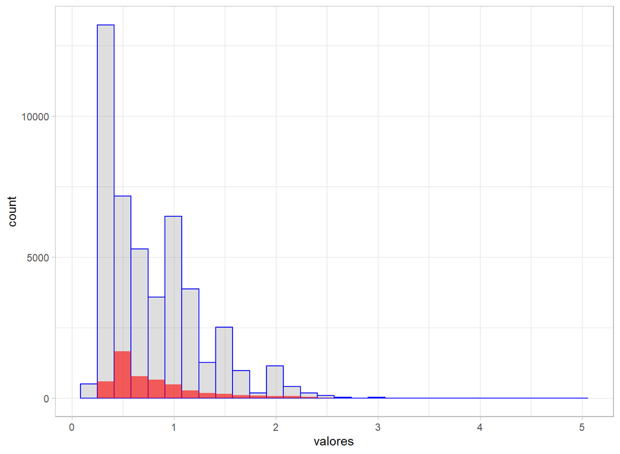

```r
# Data frame con observaciones donde carat tiene NA's y las demás variables no
caratNA<-dat1[is.na(dat1$carat) & !is.na(dat1$price) & !is.na(dat1$colorMAR),]

# Imputación de NA's por valores predichos del modelo
imputados.reg<-predict(object = ajuste,newdata =caratNA)

# Comparación de ditribuciones valores observados y valores imputados
df.compara1<-data.frame(valores=c(dat1$carat,imputados.reg),
                        tipo=c(rep("observados",length(dat1$carat)),
                               rep("imputados.reg",length(imputados.reg))))

ggplot(data=df.compara1,aes(x=valores))+
  geom_histogram(data=subset(df.compara1,tipo=="observados"),color = "blue", alpha = 0.2)+
  geom_histogram(data=subset(df.compara1,tipo=="imputados.reg"),fill = "red", alpha = 0.6)+
  theme_light()
```

### **Ejercicios**

A. Impute por regresión la variable `price`. Asuma que la relación de esta variable con las otras variables de `dat1` es lineal.

B. Compare visualmente la distribución de los valores observados con la distribución de los valores imputados por regresión de la variable `price`.

C. ¿Qué modelo de regresión utilizaría para imputar por éste método la variable `colorMAR`? Impute bajo este modelo y compare la distribución de las categorías observadas con las imputadas.

### Imputación por regresión con el paquete `mice`

- Mediante la función `mice()` del paquete del mismo nombre se puede imputar por regresión bajo distintos modelos.
- Para las variables numéricas: modelo de regresión lineal múltiple
- Para las variables categóricas: modelo de árboles de clasificación

```r
# Imputación por regresión
s <- proc.time() # Inicia el cronómetro
reg.mice<- mice(dat1, method =c("cart","norm.predict","norm.predict","cart"), seed = 1,
m = 1, print = FALSE)
ejecucions<-proc.time()-s # tiempo de ejecución

# Métodos de regresión empleados
metodos<-reg.mice$method

# Variables imputadas (valores observados más valores imputados)
varimput.reg<-mice::complete(reg.mice)

# Variables indicadores de imputación
indicadoras<-reg.mice$where
```

### Ejercicio

A. Impute por regresión la variable `price`. Utilice como modelo de soporte,un modelo con términos cuadráticos (`method="quadratic"`).

B. Compare la imputación de la variable `price` por regresión lineal con la imputación por regresión con términos cuadráticos.

# **Imputación múltiple de NA’s**

- La imputación múltiple se recomienda cuando la proporción de observaciones incompletas es grande en relación a las observaciones completas y los datos son MAR.

En esta metodologia, se toman en cuenta la información de las $X_{m-1}$ variables más correlacionadas con la variable $X_j$ donde están los valores faltantes.

- El proceso es iterativo y consiste en ajustar $m$ **modelos de regresión** para generar $m$ valores de imputación plausibles para las variables $X_j$ con NA’s.
- Los $m$ modelos propuestos dependen de la naturaleza de los datos: cuantitativa (**modelos de regresión**); cualitativa (**modelos logísticos**)
- A partir de los $m$ modelos se genera un modelo global ponderado, a partir del cual se generan un conjunto de valores predichos, que son los valores que imputan.

### **Algoritmo MICE** (*Multivariate Imputation by Chained Equations*)

Está disponible en la librería homónima permite realizar imputación múltiple. También se conoce como **imputación por regresión secuencial** o **muestreo de Gibbs**:

- En MICE, se utiliza una cadena de modelos de regresión para obtener imputaciones, lo que significa que las variables con NA’s se imputan una por una.
- Los modelos de regresión utilizan información de todas las demás variables del modelo, es decir, modelos de imputación (condicional).
- MICE tiene la ventaja de que determina automáticamente los modelos de regresión óptimos para imputación.
- Para agregar variabilidad de muestreo a las imputaciones, se agrega un error residual para crear los valores imputados. Este error residual puede agregarse directamente a los valores predichos, que es esencialmente similar a la imputación de regresión estocástica repetida en varias ejecuciones de imputación.

```r
# Aplicación del algoritmo mice con 5 réplicas y tiempo de ejecución
t1 <- proc.time() # Inicia el cronómetro
multimp.mice<-mice::mice(dat1,m = 5)
```

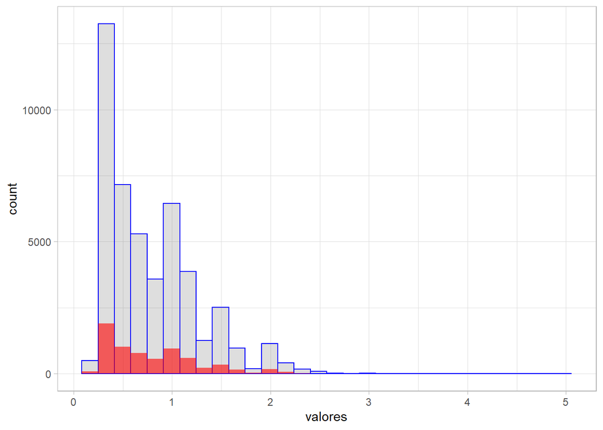

```r
ejecucion1<-proc.time()-t1

# Valores observados e imputados después de mice
after.mice<-complete(multimp.mice)

# ¿Qué valores fueron imputados?
donde<-as.data.frame(multimp.mice$where)

# ¿Qué método de imputación se utilizó para cada variable?
metodosimp<-multimp.mice$method

# Data frame con variables observadas y variables imputadas por mice
df.union<-dplyr::bind_cols(select(after.mice,2:4),select(donde,2:4))
names(df.union)<-c("carat","price","colorMAR","carat.mice","price.mice","colorMAR.mice")

# Valores imputados para la variable carat por mice
imputados_mice<-df.union[df.union$carat.mice=="TRUE","carat"]

# Data frame con variables observadas y variables imputadas por kNN
df.compara2<-data.frame(valores=c(imputados_mice,dat1$carat),
                       tipo=c(rep("imputados.mice",length(imputados_mice)),
                              rep("observados",length(dat1$carat))))

# Histogramas con variables numéricas con NA's e imputadas por kNN
ggplot(data=df.compara2,aes(x=valores))+
  geom_histogram(data=subset(df.compara2,tipo=="observados"),color = "blue", alpha = 0.2)+
  geom_histogram(data=subset(df.compara2,tipo=="imputados.mice"),fill = "red", alpha = 0.6)+
  theme_light()
```

```r
# Tabla comparación con carat observado y carat imputado
resumen2<-df.compara2%>%group_by(tipo)%>%
                 summarize("min"=min(valores,na.rm = T),
                           "media"=mean(valores,na.rm = T),
                           "sd"=sd(valores,na.rm=T),
                           "max"=max(valores,na.rm = T),
                           "Total"=n())%>%arrange(min)%>%
    knitr::kable(row.names=FALSE, align = c("l", "r", "r", "r", "r","r"),digits = 3)

resumen2
```

| tipo | min | media | sd | max | Total |
| --- | --- | --- | --- | --- | --- |
| imputados.mice | 0.2 | 0.809 | 0.476 | 3.65 | 6976 |
| observados | 0.2 | 0.797 | 0.474 | 5.01 | 53940 |

### Ejercicio

A. Compare gráficamente la distribución de valores observados de `price` con la distribución de valores imputados con mice

B. Realice la misma comparación a través de una tabla de resumen con los estadísticos de ambas distribuciones.

C. Realice un test de bondad de ajuste KS con ambas distribuciones

# **Trabajo**

El conjunto de datos `boys` está contenido en el paquete `mice` de `R`. Este conjunto de datos describe características morfológicas y demográficas (nueve variables) de $748$ jóvenes holandeces.

Con base en este conjunto realice un informe escrito donde:

$1.$ Explore, detecte y ubique los NA’s dentro del conjunto de datos; esto implica:

A. Número y porcentaje de valores NA´s con respecto a todos los valores del conjunto. Visualizar graficamente.

B. Número y porcentaje de filas con al menos un NA, con respecto al total de filas del data frame.

C. Número y porcentaje de NA’s por variables. Visualizar gráficamente.

$2.$ De acuerdo a lo obtenido en el numeral anterior, proponer y desarrollar dos técnicas de imputación de los NA’s.

$3.$ Comparar los resultados en términos de las distribuciones de variables incompletas con las variables imputadas y tests KS de bondad de ajuste.

$4.$ Determine (y justifique) el método de imputación que mejor trabajó con los datos.

$5.$ Adjunte al informe el código comentado que utilizó para realizar las tareas propuestas